Sneha Verma, Pema Choden, Tenzin Paldon

December 14, 2017 at 20:21:52

Get the data on [GitHub](https://github.com/pema-enu/MP3)

[figure not shown]

*Max Greenfield as Schmidt in “New Girl”*

If you googled [*‘movies playing near me’*](https://www.google.com/search?q=movies+playing+near+me&rlz=1C5CHFA_enUS769US769&oq=movies+playing+near+me&aqs=chrome..69i57j0l5.2614j0j7&sourceid=chrome&ie=UTF-8), chances are that you will find that a good number of the results are remakes or sequels. And why not?

Viewers want to find out how the story ends but we also want to know what comes after the ending as stated by David Brewer in *The Afterlife of a Character*. That is why cliffhangers exist, because Hollywood knows the audience always wants more. So it should not surprise you to find several remakes and sequels of your favorite movies - or any movie really.

Take for example the Star Wars franchise. There are currently 10 Star Wars movies with The [Last Jedi](http://www.imdb.com/title/tt2527336/) coming out on December 15th of this year and [Star Wars Episode IX](http://www.imdb.com/title/tt2527338/) scheduled to release in December, 2019.

How often are remakes or sequels made? Is Hollywood more repetitive than it’s ever been? Follow us to find out whether or not the trend of sequels is new to the cinematic world. To demystify this new (or as you will later learn - not so new) trend we looked at data from imdb to find out the average time (in years) between the production of an original and it’s sequels.

We wanted to study if the trend of sequels and remakes truly are the new fad in cinema, or if it has existed since the beginning of film industry.We wanted to see if this trend was similar across popular genres like Action, Horror, Thriller, Romance, etc. What we found was that trends in sequels, remakes and spin-offs vary across movie genres.

```r
library(mdsr)
library(RMySQL)
library(tidyverse)
library(DT)
db <- dbConnect_scidb(dbname = "imdb")
```

```r
#All movies that are either sequels, remakes, spin offs or different versions of an original

rep <- "SELECT t.id, title, kind_id, production_year, linked_movie_id, mi.info as genre, mi2.info as country, mi3.info as runtimes, link_type_id
FROM imdb.title t
#join to see how a movie is linked to another movie
JOIN movie_link ml
    ON t.id = ml.movie_id
#join to see info on movie like genre and country
JOIN movie_info mi
  ON t.id = mi.movie_id
#second join with title and movie_info to see genre and country
JOIN movie_info mi2
  ON t.id = mi2.movie_id
JOIN movie_info mi3
  ON t.id = mi3.movie_id
JOIN movie_info_idx mii
  ON t.id = mii.movie_id
WHERE kind_id = 1 AND
      #look at data from full years
      t.production_year < 2017 AND
      #movies that are sequels, remakes, spin offs or a version of       the original
      ml.link_type_id IN (1,3,11,13) AND
      #see genres of all movies
      mi.info_type_id = 3 AND
      #filter for only U.S made movies
      mi2.info = 'USA' AND
      #filter for feature length movies (length greater than 80 m)
      mi3.info_type_id = 1 AND mi3.info >= 80 AND
      #
      mii.info_type_id = 100 AND mii.info > 1000
GROUP BY t.id
ORDER BY production_year;
"

#save rep as a dataframe in R
repetitions <-db%>%
  dbGetQuery(rep)
```

```r
link <- "SELECT *
from link_type
Where id IN (1,3,11,13);"

links <- db%>%
  dbGetQuery(link)
```

```r
#view the link_type of each movie
link_type <- repetitions %>%
  inner_join(links, by = c("link_type_id" = "id"))

#omit null values
link_types <- na.omit(link_type)
```

```r
#Filter to see most popular genres
linktype1 <- link_types %>%
  group_by(production_year, link) %>%
  mutate(total_reps = count(link)) %>%
  filter(genre %in% c("Comedy", "Romance", "Action", "Thriller","Horror", "Animation", "Family"))
```

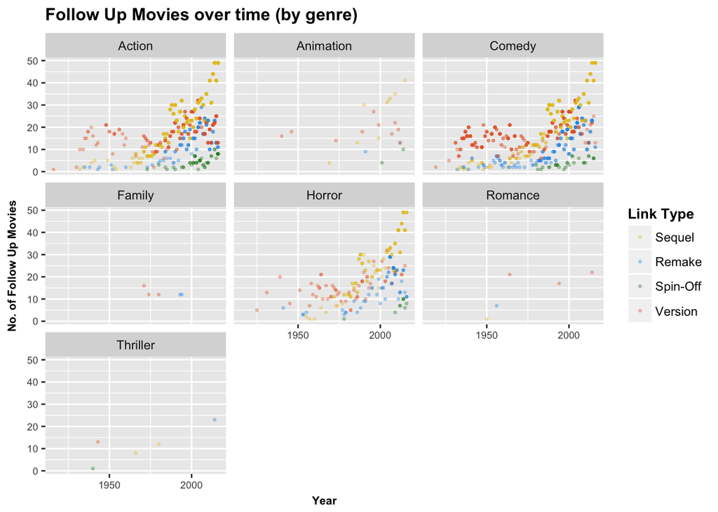

```r
#Which genre has the most sequels and remakes?
ggplot(linktype1, aes(x = production_year, y = total_reps, col = link))+
  ggtitle("Follow Up Movies over time (by genre)")+
  scale_x_continuous("Year",
                     breaks = seq(0,2020,50))+
  scale_y_continuous("No. of Follow Up Movies")+
  scale_color_manual(values = c("#E6C42C","#2C9AE6","#1F8325","#E6612C"),
                     name = "Link Type",
                     breaks = c("follows", "remake of", "spin off from", "version of"),
                     labels = c("Sequel", "Remake", "Spin-Off", "Version"))+
  geom_point(size = 0.6, alpha = 0.3) +
  facet_wrap(~genre)+
  theme(title = element_text(face = "bold", size = 10),
        axis.title.x = element_text(size = 8),
        axis.title.y = element_text(size = 8),
        axis.text.x = element_text(size = 7),
        axis.text.y = element_text(size = 7))
```

On a general scale however, Hollywood has always been repetitive. As Briana Jones (2016) states,

> *“Hollywood has always been awash in sequels, remakes, and reboots.”*

In fact all forms of storytelling have always made use of repetition, retelling the story to keep it interesting for a new audience and so, alive for a long time[^3].

Homer’s Odyssey is in part a sequel to Iliad. After oral poetry and storytelling, books are the oldest and most popular medium of entertainment. Some of the best sellers in the late Victorian Era such as Robinson Crusoe (1719) and Gulliver’s Travels (1726) brought huge revenue to the publishers(Den of Geek).

As a result of this huge economic gain, the publishers produced sequels like Memoirs of the Court of Lilliput (1727) and The New Gulliver (1730). This trend still exists in present day in TV Shows, books, and movies.

# **Has Hollywood started reproducing films faster?**

```r
#Filter for only sequels (link_type_id = 1)

sequels <- repetitions%>%
  filter(link_type_id == 1)
```

```r
#Adding the production_year of prequel

sql2 <- "SELECT id, title, production_year as prequel_release_year
FROM title
WHERE kind_id = 1
Group by id
;"

prequel_release <- db%>%
  dbGetQuery(sql2)
```

```r
#Join sequels tbl and prequel_release tbl

movies <- sequels %>%
  #join so that the sequels are linked to their prequels
  inner_join(prequel_release, by = c("linked_movie_id" = "id")) %>%
  #rename columns to make tbl easier to read
  rename(title = title.x, prequel_title = title.y) %>%
  #find the time between orginal and sequels for each movie
  mutate(time_between_sequels = production_year - prequel_release_year)

#omit NA values
movies <- na.omit(movies)

#COUNT IF  sequels came out within 10 years of the original
movies <- movies %>%
  filter(time_between_sequels <= 10)

#Find the average time between originals and their sequels by year
diff_prod <- movies %>%
  group_by(prequel_release_year)%>%
   filter(genre %in% c("Comedy", "Romance", "Action", "Thriller","Horror", "Animation", "Family")) %>%
  mutate(avg_difference = mean(time_between_sequels))
```

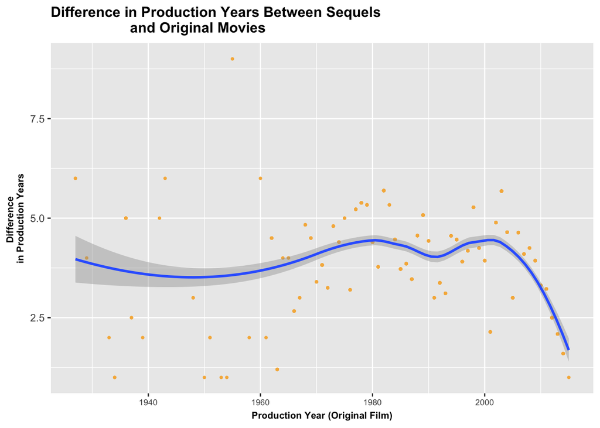

```r
#create ggplot
ggplot(diff_prod, aes(x = prequel_release_year, y = avg_difference))+
  #add a title
  ggtitle("Difference in Production Years Between Sequels
                    and Original Movies")+
  geom_point(col = "#F6B54A", size = 0.7)+
  #create a line to see a general trend
  geom_smooth()+
  #geom_smooth(col = "#0F75EA", size = 0.4, linetype = 1)+
  scale_x_continuous("Production Year (Original Film)",
                     breaks = seq(0,2020,20))+
  scale_y_continuous("Difference
in Production Years")+
  theme(title = element_text(face = "bold", size = 10),
        axis.title.x = element_text(size = 8),
        axis.title.y = element_text(size = 8),
        axis.text.x = element_text(size = 7))
```

In the graph above[^4], the trend seems to show that sequels are being produced at a much faster rate than they were before. The average difference between the the production year of the sequels and its orignal has become smaller as we enter the 21st century. So eventhough Hollywood has always been repetitive, in more recent years it’s repetitiveness is becoming more apparent than it actually was.

The first film, or show is the riskiest and most expensive. The makers have to invest a huge amount of money in advertising, building the story plot, costumes, etc. After the success of the original, there is a target population, set theme and story, and more budget to produce the sequels (Sola, 2016). As a result, sequels are relatively low risk and easier for the film makers or publishers to get behind (Rosen, 2011).

Moreover we need to keep in mind that the US is NOT the only target audience for Hollywood. North America contributes to only 1/3 of Hollywood’s total income (The Economist, 2011). The rest of world including many Asian and African countries also add to Hollywood’s revenue. The remakes might be boring and repetitive to the American audience, but they are fresh and new to the 2/3 of Hollywood’s income generators (The Economist, 2011). Therefore, Hollywood might not stop cashing in on the success of the originals right away!

Despite the advantage of sequel making, there has been a lot of criticism against remakes and sequels in Hollywood (USA Today, 2016). Steven Spielberg (arguably one of the most popular directors in Hollywood) shared his concerns about this trend to Hollywood Reporter in June:

> *“There’s going to be an implosion where three or four or maybe even a half-dozen mega budget movies are going to go crashing into the ground, and that’s going to change the paradigm.”*

Ironically, Spielberg himself is guilty of following this trend in 1997 when he directed the film [*The Lost World: Jurassic Park*](http://www.imdb.com/title/tt0119567/) a sequel to Jurassic Park. However, we share his concerns and believe that there should be more diverse stories and film making styles in the industry.

Why? Because otherwise, Hollywood will not be considered a platform of entertainment that people could turn to. The continuation of a lack of creativity could also mean that Hollywood will not a major source of employment if this trend continues. Even though it would take a long time for this to happen and hopefully never does but with the age of the cell-phone one never knows. Hollywood needs an increase in creativity if it wants to still be considered a platform of entertainment that people turn to. As we mentioned before they are now many sources of entertainment available to people.

The tried and tested formula of making profit from sequels does not seem to be foolproof anymore. Since 2015, the number of failed sequels seems to have increased as found by McClintock, 2016. The audience is demanding more creativity and originality from Hollywood. In 2016, multiple sequels have failed such as The Divergent Series: Allegiant, Zoolander 2, The Huntsman: Winter’s War, War of the Planet of Ape. Even franchises like Pirates of the Caribbean is failing to cash in on the success of its prequels.

With alternate entertainment options such as TV shows (like Game of Thrones), Web Series, YouTube, Netflix, Hulu etc., people do not have to watch movies or they can choose not to watch them in theaters. If Hollywood continues with the trend of making sequels and remakes, the audience does not have any incentive to spend their hard-earned money on a plotline they’ve probably already seen before.

Will Hollywood keep making sequels to popular movies to cater to curiosity and cash in? Or will the American film industry favor more fresh and original storylines?

## Sources

Bogage, Jacob. “Why film studios really like movie remakes” *Chicago Tribune* 20 Nov., 2017: Web.

Brewer, David A. The Afterlife of Character, 1726-1825. Philadelphia: University of Pennsylvania, 2005. Print.

Jones, Briana on March 2, 2016. “Can You Guess The Very First Movie Sequel, Remake, And Reboot Ever?” All That Is Interesting, 2 Mar. 2016, all-that-is-interesting.com/first-movie-sequel. Lambie, Ryan. “The origins and evolution of the movie sequel” *Den of Geek* 22 May, 2011: Web.

Mandell, Andrea. “Grading the summer sequels:Which movies failed?” *USA Today* 9 July, 2017: Web. McClintock, Pamela. “Sequels Moviegoers Don’t Want” *The Hollywood Reporter* 5 June, 2016: Web.

Mendelson, Scott. “Box Office: Kevin Hart’s ‘Think Like A Man Too’ Tops Weekend With $30M.” Forbes, Forbes Magazine, 22 June 2014.

Merry, Stephanie. “Moviegoers are sick of sequels. Here’s why ‘Blade Runner 2049’ will go against the trend.” *The Washington Post* 7 Oct, 2017: Web.

Mukherjee, P. (1981). The History of Medieval Vaishnavism in Orissa. Asian Educational Services. p. 74. ISBN 9788120602298. Retrieved 6 January 2017.

Rosen, David (June 15, 2011). “Creative Bankruptcy”. Call It Like I See It.

Sola, Katie. “Want To Produce A Profitable Movie? Make A Sequel.” Forbes, Forbes Magazine, 25 Feb. 2016, www.forbes.com/sites/katiesola/2016/02/25/want-to-produce-a-profitable-movie-make-a-sequel/.

Stephen, F. “The Scale of Hollywood remakes and reboots” *Stephen Follows* 22 June, 2015: Web.

The Economist. “Bigger Abroad.” The Economist, The Economist Newspaper, 19 Feb. 2011, www.economist.com/node/18178291.

[^2]: Only one sequel in the romantic-comedy genre, [*Think Like a Man Too*](http://www.imdb.com/title/tt2239832/) made it in the top 100 grossing films of the year between 2005 to 2014 (Mendelson, 2014)
[^3]: The Hindu epic poem [*Ramayana*](https://www.britannica.com/topic/Ramayana-Indian-epic) has many retellings in several languages like Tamil, Bengali, etc. It is written in 7 parts or *kandas* (Mukherjee, 1981)
[^4]: We are only looking at movies with runtimes of atleast 80 minutes. Older movies have a greater opportunity of being remade or having a sequel so we are only looking at sequels that came out within 10 years of the production of the original film